# R Notebook

# Iron Overload

## 1. Import Dataset

The processed data was downloaded from GEO (GSE3573). This has the expression already summarised to probe-set level. I wanted the raw probe intensities, but when I tried to download this from GEO, there was only an annotation text file in the .tar. No raw data files unfortunately.

**Summary of the study**:

> We investigated transcriptional response of CaCo-2 cells to iron treatments, we studied hemin effect by adding hemin to DMEM-FBS medium and iron deficiency effects in using an iron free medium compared to the same supplemented with FAC (ferric ammonium citrate). Keywords: various iron treatment, differential gene expression, hemin treatment, iron-free

```r
geo <- getGEO("GSE3573", GSEMatrix = TRUE)
```

```
Found 1 file(s)
GSE3573_series_matrix.txt.gz
==================================================

File stored at:
/var/folders/mf/j7h9p8l55k9fb0rgm_f753cc0000gn/T//RtmpcT80p6/GPL887.soft
```

```r
exprs <- geo$GSE3573_series_matrix.txt.gz@assayData$exprs
samples <- geo$GSE3573_series_matrix.txt.gz@phenoData@data
annot <- geo$GSE3573_series_matrix.txt.gz@featureData@data
dim(annot)
```

```
[1] 22153    20
```

```r
dim(exprs)
```

```
[1] 22153    12
```

```r
exprs %>%
  as.data.frame %>%
  melt %>%
  group_by(variable) %>%
  dplyr::summarise(min = min(value),
                   max = max(value))
```

| variable | min | max |
| --- | --- | --- |
| GSM81961 | -1.80 | 0.713 |
| GSM81962 | -2.00 | 0.724 |
| GSM81963 | -1.99 | 1.060 |
| GSM81964 | -2.00 | 0.799 |
| GSM81965 | -1.72 | 0.801 |
| GSM81966 | -1.78 | 1.960 |
| GSM81967 | -1.79 | 0.713 |
| GSM81968 | -1.78 | 0.707 |
| GSM81969 | -2.00 | 0.770 |
| GSM81970 | -1.90 | 0.618 |

[output cut: 2 more lines]

A bit of formatting:

```r
exprs %<>% set_rownames(annot$NAME)
samples %<>% dplyr::select(title,
                           geo_accession,
                           treatment_protocol_ch1) %>%
  dplyr::mutate(treatment = c(rep("DMEM_FBS_Medium", 3),
                              rep("DMEM_FBS_Medium_and_Hemin", 3),
                              rep("Ironfree_Medium", 3),
                              rep("Ironfree_Medium_and_FAC", 3)))
  #dplyr::select(title, geo_accession, treatment)
samples
```

```
                title geo_accession
1    CaCo2-DMEM-FBS_a      GSM81961
2    CaCo2-DMEM-FBS_b      GSM81962
3    CaCo2-DMEM-FBS_c      GSM81963
4  CaCo2-DMEM-Hemin_a      GSM81964
5  CaCo2-DMEM-Hemin_b      GSM81965
6  CaCo2-DMEM-Hemin_c      GSM81966
7        CaCo2-SF-0_a      GSM81967
8        CaCo2-SF-0_b      GSM81968
9        CaCo2-SF-0_c      GSM81969
10     CaCo2-SF-FAC_a      GSM81970
11     CaCo2-SF-FAC_b      GSM81971
12     CaCo2-SF-FAC_c      GSM81972
                                                                                                           treatment_protocol_ch1
1                                                     Fully differentiated CaCo-2 cells were submitted to DMEM 10% FBS (DMEM-FBS)
```

[output cut: 24 more lines]

## 2. Principal Component Analysis

```r
pca <- exprs %>% t %>% prcomp()
summary(pca)
```

```
Importance of components:
                          PC1    PC2    PC3    PC4     PC5     PC6     PC7     PC8     PC9    PC10    PC11      PC12
Standard deviation     4.9277 3.6810 3.3714 3.1741 2.74548 2.58338 2.43438 2.26567 2.17775 2.17046 2.01944 1.601e-14
Proportion of Variance 0.2476 0.1381 0.1159 0.1027 0.07686 0.06805 0.06043 0.05234 0.04836 0.04803 0.04158 0.000e+00
Cumulative Proportion  0.2476 0.3857 0.5016 0.6044 0.68121 0.74926 0.80969 0.86203 0.91038 0.95842 1.00000 1.000e+00
```

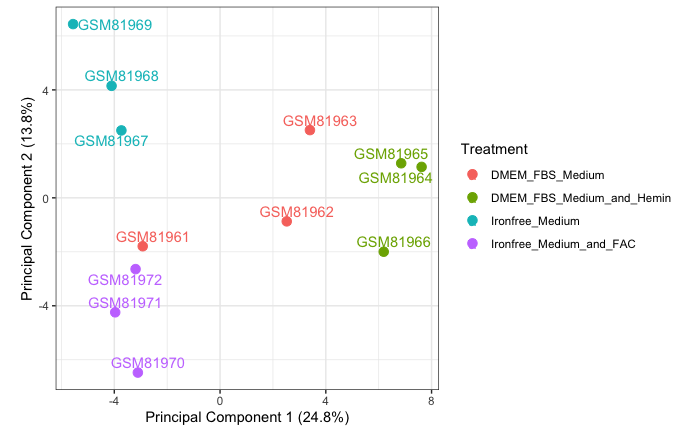

```r
pca_plot_GSE3573 <- pca$x %>% as.data.frame %>%
  rownames_to_column("geo_accession") %>%
  left_join(samples, by = "geo_accession") %>%
  ggplot(aes(x = PC1, y = PC2, colour = treatment)) +
  geom_point(size=3) +
  ggrepel::geom_text_repel(aes(label = geo_accession)) +
  theme(aspect.ratio = 1) +
  labs(x = "Principal Component 1 (24.8%)",
       y = "Principal Component 2 (13.8%)",
       colour = "Treatment")
pca_plot_GSE3573
```

```r
#export::graph2ppt(pca_plot_GSE3573, here::here("R/IronDepleted/fig/pca_plot_GSE3573"))
#saveRDS(pca_plot_GSE3573, here::here("R/IronDepleted/fig/pca_plot_GSE3573.rds"))
#pca_plot_GSE3573 <- readRDS(here::here("R/IronDepleted/fig/pca_plot_GSE3573.rds"))
```

## 3. Annotation

## 4. DE analysis

```r
results %>% summary()
```

```
       IronOverload IronDeficiency
Down             55             65
NotSig        21941          22057
Up              157             31
```

### 4.1. Volcano Plot

- The following volcano plots indicate the genes determined to be DE (FDR-adjusted p-value < 0.05) under iron overload and iron deficiency treatments.

[figure not shown]

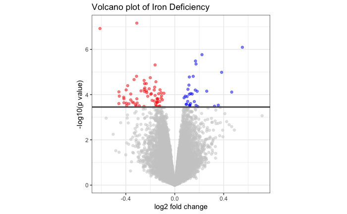

```r
volcanoPlot_ironDeficiency
```

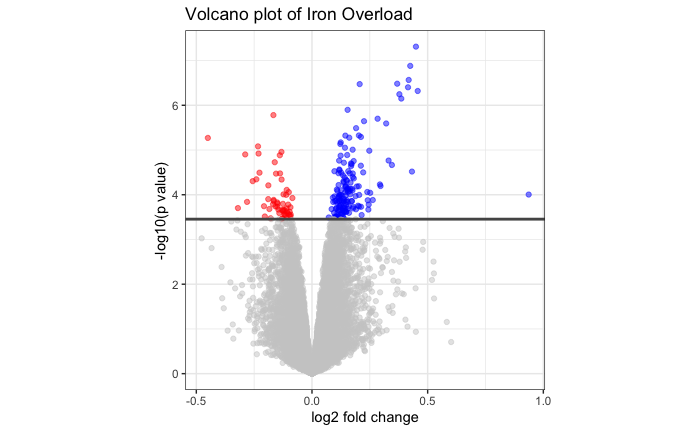

```r
volcanoPlot_ironOverload
```

## 5. Gene set enrichment tests

- We will perform enrichment testing on the following gene sets:
  - Hallmark collection from MSigDB
  - Human predicted IRE gene sets
- First we need to format the expression matrix properly. At the moment, the rownames of the expression matrix don’t correspond to only one type of gene ID (some RefSeq, some probes, etc.). Although we are going to have to lose some information, we will collapse them down to representative Ensembl IDs.
- Instead of using the `voom` object from *limma*, because this is a microarray dataset we will need to use the `fit` object and expression object.

```r
# Combine the expression data with annotations
gene2trans <- as.data.frame(org.Hs.egENSEMBLTRANS) %>%
  left_join(as.data.frame(org.Hs.egENSEMBL))%>%
  set_colnames(c("ENTREZ", "ENSEMBL_ID", "ENSEMBL"))
annot %<>% left_join(gene2trans, by = "ENSEMBL_ID")

datET <- exprs %>%
  as.data.frame %>%
  rownames_to_column("NAME") %>%
  left_join(annot, by = "NAME") %>%
  mutate(GENE = as.character(GENE)) %>%
  left_join(gene2trans, by = c("GENE"="ENTREZ")) %>%
  dplyr::filter(ENSEMBL != "" | !is.na(ENSEMBL)) %>%
  dplyr::distinct(ENSEMBL, .keep_all = TRUE) %>%
  set_rownames(.$ENSEMBL)

# Collapse rows
collapsed <- WGCNA::collapseRows(datET[,2:13],
                          rowGroup = datET$ENSEMBL,
                          rowID = rownames(datET),
                          method ="MaxMean")

colExprs <- collapsed$datETcollapsed
colExprs <- datET[,2:13]
 dim(colExprs)  #  7,793 genes remaining

colAnnot <- data.frame(ENSEMBL = rownames(colExprs)) %>%
  left_join(annot, by = "ENSEMBL") %>%
  dplyr::distinct(ENSEMBL, .keep_all = TRUE)

newFit <- lmFit(colExprs, design) %>%
  contrasts.fit(contrasts) %>%
  eBayes()

results <- decideTests(newFit,
                       p.value = 0.05,
                       adjust.method = "fdr",
                       method = "global")

results %>% summary()
```

[output not shown]

- The number of DE genes has been lowered due to cutting out a lot of genes, but we’ll proceed ahead anyway to see what the results look like.
- We will perform enrichment testing in a combined way by putting all of the gene sets together.

```r
source(here::here("R/GSEA/combinedGSEA_ma.R"))
humanIreGenes <- readRDS(here::here("R/IREGenes/data/human_ireGenes.rds"))

genesetsDir <- here::here("R", "GSEA", "data", "human")
h_mapped <- readRDS(file.path(genesetsDir, "ens_h_mapped.rds"))


# Build index specific to the ordering of the rownames in the expression matrix
humanIreIdx <- limma::ids2indices(humanIreGenes,
                                  identifiers = rownames(colExprs))

humanHallmarkIdx <- limma::ids2indices(h_mapped, identifiers = rownames(colExprs))

combinedIdx <- c(humanIreIdx, humanHallmarkIdx)

ireEnr <- combinedGSEA_ma(colExprs,
                          fit = newFit,
                          design = design,
                          contrasts = contrasts,
                          idx = humanIreIdx)

hEnr <- combinedGSEA_ma(colExprs,
                          fit = newFit,
                          design = design,
                          contrasts = contrasts,
                          idx = combinedIdx)
# Results
ireEnr
hEnr

# Export
ireEnr %>% saveRDS(here::here("R/IronDepleted/data/GSE3573_ireEnr.rds"))
hEnr %>% saveRDS(here::here("R/IronDepleted/data/GSE3573_hEnr.rds"))
```

[output not shown]

### 5.1. Butterfly plot

- The GSEA results can be visualised using a back-to-back barchart.

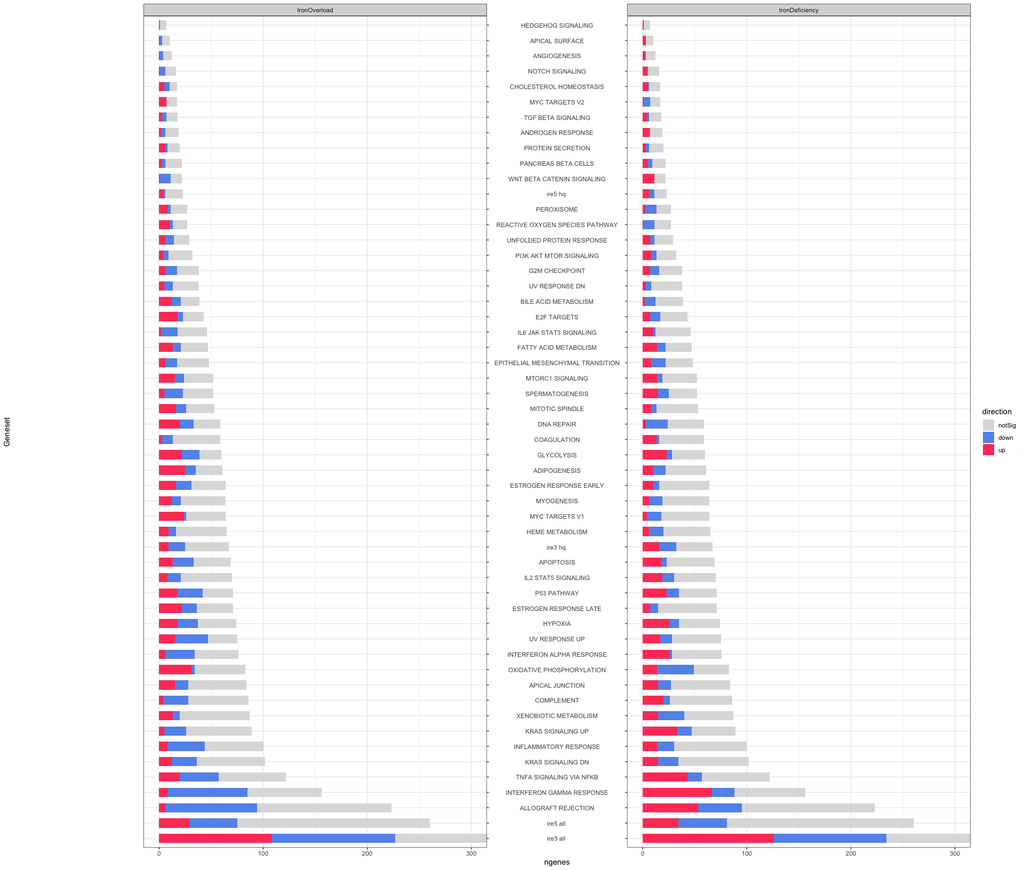